# Plots

baj

#Graf over hvem siger noget hvornår

Det her er simpelthen en anden måde at visualisere, hvornår karaktererne taler i stykket.

## Indlæs data

```r
library(tidyverse)
library(tidytext)
library(readxl)
library(here)
library(ndjson)
#library(xslt)
library(fs)
library(ggplot2)
library(knitr)
library(dplyr)

require(readr)  # for read_csv()
require(purrr)  # for map(), reduce()

source(here("src/p017-functions.R"))
source(here("src", "present_without_speech.R"))

#convert_TEI_to_JSONL(here("test-data"))
# my_file <- "Skibbrud_mod.jsonl"
# my_file <- "Sganarel_mod.jsonl"
my_file <- "Barselstuen_mod.jsonl" #bliver meget klemt!
# my_file <- "Mascarade_mod.jsonl"
my_play <- read_play_jsonl(here("test-data", my_file))
my_play
```

| filename | act | act_number | docTitle | index | scene | scene_number | speaker | speaker_stage | spoke | stage | title | type | year |
| --- | --- | --- | --- | --- | --- | --- | --- | --- | --- | --- | --- | --- | --- |
| Barselstuen_mod.jsonl | Første akt | 1 | Barselsstuen Komedie | 1 | Scene 1 | 1 | Troels | ( tager op et stykke smalt papir men så langt som det hele theatrum) | NA | NA | Barselsstuen | 3 | (1724) |
| Barselstuen_mod.jsonl | Første akt | 1 | Barselsstuen Komedie | 2 | Scene 1 | 1 | Troels | NA | Maren Hansdatter, Barbara Per Nielsens, Abelone Hans Hansens, Christine Erik Eriksens, Engelke Jens Hattemagers, Lusse Frands Buntmagers, Vibeke Per Guldbrandsens, Maren Christopher Skrædders, Elsebet… | NA | Barselsstuen | 4 | (1724) |
| Barselstuen_mod.jsonl | Første akt | 1 | Barselsstuen Komedie | 3 | Scene 1 | 1 | Troels | NA | Skal man giftes, må der lige så mange folk komme sammen for at æde og drikke op mere end en stakkels håndværksmand kan fortjene i fire år igen. Derfor har man hittet på den mode i gamle dage at den ha… | NA | Barselsstuen | 4 | (1724) |
| Barselstuen_mod.jsonl | Første akt | 1 | Barselsstuen Komedie | 4 | Scene 1 | 1 | Troels | NA | Vil jeg begive mig fra bryllupper til begravelser, da finder jeg lige så megen galskab ved de sidste som ved de første. En stakkels kone mister sin mand, som jeg sætter efterlader hende nogle skilling… | NA | Barselsstuen | 4 | (1724) |
| Barselstuen_mod.jsonl | Første akt | 1 | Barselsstuen Komedie | 5 | Scene 1 | 1 | Troels | NA | Men disse barselsstuer er rent ravgale. Her skal først et hundrede mennesker gives til kende som et stort vidunder at Hans Hansen eller Jespersen har gjort det mesterstykke ved sin kone som enhver bon… | NA | Barselsstuen | 4 | (1724) |
| Barselstuen_mod.jsonl | Første akt | 1 | Barselsstuen Komedie | 6 | Scene 1 | 1 | Troels | NA | Men hvem pokker er det som kommer så løbende? Det er Christophersens karl. Hvad mon han vil? | NA | Barselsstuen | 4 | (1724) |
| Barselstuen_mod.jsonl | Første akt | 1 | Barselsstuen Komedie | 1 | Scene 2 | 2 | NA | NA | NA | Claus, Troels | Barselsstuen | 1 | (1724) |
| Barselstuen_mod.jsonl | Første akt | 1 | Barselsstuen Komedie | 2 | Scene 2 | 2 | Claus | NA | Ak, kære Troels, veksl mig en toskilling for to eneste skillinger! | NA | Barselsstuen | 4 | (1724) |
| Barselstuen_mod.jsonl | Første akt | 1 | Barselsstuen Komedie | 3 | Scene 2 | 2 | Troels | NA | Hvad vil du med de eneste skillinger? | NA | Barselsstuen | 4 | (1724) |
| Barselstuen_mod.jsonl | Første akt | 1 | Barselsstuen Komedie | 4 | Scene 2 | 2 | Claus | NA | Jeg vil give en for at komme op i det runde tårn. | NA | Barselsstuen | 4 | (1724) |

[output cut: 990 more lines]

## Navnevarianter

```r
# Indlæs Excelarket
variants <- read_excel(here("Rolleliste.xlsx")) %>%
  unnest_tokens(variant, Alias, token = "regex", pattern = ", ") %>%
    mutate(
      Karakter = tolower(Karakter),
      variant = tolower(variant)
    )
# Benyt excelark til at samle varianter
my_play %>%
  mutate(speaker = tolower(speaker)) %>%
  left_join(variants, by = c("filename"="Filnavn", "speaker"="variant")) %>%
  mutate(speaker = if_else(!is.na(Karakter), Karakter, speaker)) %>%
  filter(!is.na(speaker), !(speaker=="")) %>%
  distinct -> my_play
```

## Tilføj scene indeks

```r
my_play %>%
   group_by(act_number)  %>%
   summarise(scenes = max(scene_number)) %>%
   pull(scenes) %>% cumsum() -> act_length

act_length
```

```
[1]  7 21 28 37 44
```

```r
calc_scene_index <- function(act_number, scene_number, act_length) {
   ifelse(is.numeric(scene_number),
      scene_number + ifelse(act_number==1, 0, act_length[act_number-1]),
      NA
   )
}
```

## Omstrukturer data

Det bliver måske pænere, hvis vi transformerer det til “den rigtige csv”.

Husk også at tælle hvor mange, der er til stede!

```r
my_play %>%
  # add a scene index for the x-axis
  rowwise() %>%
  mutate(scene_index = calc_scene_index(act_number, scene_number, act_length)) %>%
  # remove rows that are not dialogue
  filter(act != "", scene != "", speaker != "", !is.na(spoke)) %>%
  # make a boolean to indicate spoke
  mutate(boolean_spoke = (if (spoke != "") {"X"} else {"Y"})) %>%
  # keep only coloumns that we need
  select(act_number, scene_number, scene_index, speaker, boolean_spoke) %>%
  distinct() -> my_summary

(my_summary %>%
  # make a small scene_index, act_number, scene_number table
  select(scene_index, act_number, scene_number) %>%
  distinct() -> my_acts_and_scenes)
```

| scene_index | act_number | scene_number |
| --- | --- | --- |
| 1 | 1 | 1 |
| 2 | 1 | 2 |
| 3 | 1 | 3 |
| 4 | 1 | 4 |
| 5 | 1 | 5 |
| 6 | 1 | 6 |
| 7 | 1 | 7 |
| 8 | 2 | 1 |
| 9 | 2 | 2 |
| 10 | 2 | 3 |

[output cut: 34 more lines]

```r
(my_acts_and_scenes %>% pull(act_number) -> my_acts)
```

```
 [1] 1 1 1 1 1 1 1 2 2 2 2 2 2 2 2 2 2 2 2 2 2 3 3 3 3 3 3 3 4 4 4 4 4 4
[35] 4 4 4 5 5 5 5 5 5 5
```

```r
my_summary %>%
  # select only the columns, that we are interested in
  select(scene_index, speaker, boolean_spoke) %>%
  distinct() %>%
  # now pivot speakers to rows
  pivot_wider(names_from = scene_index, values_from = boolean_spoke) -> my_speakers

# now remove NA
my_speakers[is.na(my_speakers)] <- ""
my_speakers
```

| speaker | 1 | 2 | 3 | 4 | 5 | 6 | 7 | 8 | 9 | 10 | 11 | 12 | 13 | 14 | 15 | 16 | 17 | 18 | 19 | 20 | 21 | 22 | 23 | 24 | 25 | 26 | 27 | 28 | 29 | … |
| --- | --- | --- | --- | --- | --- | --- | --- | --- | --- | --- | --- | --- | --- | --- | --- | --- | --- | --- | --- | --- | --- | --- | --- | --- | --- | --- | --- | --- | --- | --- |
| troels | X | X | X |  |  | X | X |  |  |  |  |  |  |  |  |  |  |  |  |  |  |  |  |  |  |  |  |  | X | … |
| claus |  | X |  |  |  |  |  |  |  |  |  |  |  |  |  |  |  |  |  |  |  |  |  |  |  |  |  |  |  | … |
| corfitz |  |  | X | X | X | X | X | X |  |  |  |  | X |  |  |  |  | X |  |  | X |  |  |  |  |  |  |  |  | … |
| jeronimus |  |  |  |  | X | X |  |  |  |  |  |  |  |  |  |  |  |  |  |  |  |  |  |  |  |  |  |  |  | … |
| en pige |  |  |  |  |  |  | X | X |  |  |  |  |  |  |  |  |  |  |  |  |  |  |  |  |  | X |  |  |  | … |
| barselskvinden |  |  |  |  |  |  |  | X | X | X | X | X | X | X | X | X | X | X | X |  | X |  | X | X | X | X | X | X |  | … |
| ammen |  |  |  |  |  |  |  | X |  |  |  |  |  |  |  |  |  |  |  |  |  |  |  |  |  |  |  |  |  | … |
| 1. dame |  |  |  |  |  |  |  |  | X | X |  |  |  |  |  |  |  |  |  |  |  | X |  |  |  | X |  |  |  | … |
| 2. dame |  |  |  |  |  |  |  |  | X | X |  |  |  |  |  |  |  |  |  |  |  | X |  |  |  | X |  |  |  | … |
| anne kandestøbers |  |  |  |  |  |  |  |  |  | X | X | X |  |  |  |  |  |  |  |  |  |  |  | X |  |  |  |  |  | … |

[output cut: 30 more lines]

```r
# TODO add act_number and scene_number again
# (my_speakers %>% add_row(my_acts))

#Skriv til csv
write.csv(my_speakers, file = here(paste("csv/","plot_who_speaks_", my_file, ".csv")))

# Pretty print my_speakers
# install.packages("DT")
library(DT)
datatable(my_speakers)
```

|  | speaker | 1 | 2 | 3 | 4 | 5 | 6 | 7 | 8 | 9 | 10 | 11 | 12 | 13 | 14 | 15 | 16 | 17 | 18 | 19 | 20 | 21 | 22 | 23 | 24 | 25 | 26 | 27 | 28 | … |
| --- | --- | --- | --- | --- | --- | --- | --- | --- | --- | --- | --- | --- | --- | --- | --- | --- | --- | --- | --- | --- | --- | --- | --- | --- | --- | --- | --- | --- | --- | --- |
| 1 | troels | X | X | X |  |  | X | X |  |  |  |  |  |  |  |  |  |  |  |  |  |  |  |  |  |  |  |  |  | … |
| 2 | claus |  | X |  |  |  |  |  |  |  |  |  |  |  |  |  |  |  |  |  |  |  |  |  |  |  |  |  |  | … |
| 3 | corfitz |  |  | X | X | X | X | X | X |  |  |  |  | X |  |  |  |  | X |  |  | X |  |  |  |  |  |  |  | … |
| 4 | jeronimus |  |  |  |  | X | X |  |  |  |  |  |  |  |  |  |  |  |  |  |  |  |  |  |  |  |  |  |  | … |
| 5 | en pige |  |  |  |  |  |  | X | X |  |  |  |  |  |  |  |  |  |  |  |  |  |  |  |  |  | X |  |  | … |
| 6 | barselskvinden |  |  |  |  |  |  |  | X | X | X | X | X | X | X | X | X | X | X | X |  | X |  | X | X | X | X | X | X | … |
| 7 | ammen |  |  |  |  |  |  |  | X |  |  |  |  |  |  |  |  |  |  |  |  |  |  |  |  |  |  |  |  | … |
| 8 | 1. dame |  |  |  |  |  |  |  |  | X | X |  |  |  |  |  |  |  |  |  |  |  | X |  |  |  | X |  |  | … |
| 9 | 2. dame |  |  |  |  |  |  |  |  | X | X |  |  |  |  |  |  |  |  |  |  |  | X |  |  |  | X |  |  | … |
| 10 | anne kandestøbers |  |  |  |  |  |  |  |  |  | X | X | X |  |  |  |  |  |  |  |  |  |  |  | X |  |  |  |  | … |

[output cut: 30 more lines]

```r
NA
```

“my_speakers” indeholder faktisk det jeg gerne vil plotte; jeg kan bare ikke finde ud af at lave plottet ud fra den tibble! Jeg går tilbage til at bruge “my_summary”, selvom den ikke ser så pæn ud

#Graf over hvem der taler

```r
my_play %>%
  select(docTitle) %>%
  distinct() %>%
  pull(1,1) -> my_title

my_play %>%
  select(year) %>%
  distinct() %>%
  pull(1,1) -> my_year

#Husk at tælle hvor mange der NU er på scenen
(my_summary %>%
  group_by(act_number, scene_number) %>%
  mutate(total = sum(n_distinct(speaker))) -> my_summary)
```

| act_number | scene_number | scene_index | speaker | boolean_spoke | total |
| --- | --- | --- | --- | --- | --- |
| 1 | 1 | 1 | troels | X | 1 |
| 1 | 2 | 2 | claus | X | 2 |
| 1 | 2 | 2 | troels | X | 2 |
| 1 | 3 | 3 | corfitz | X | 2 |
| 1 | 3 | 3 | troels | X | 2 |
| 1 | 4 | 4 | corfitz | X | 1 |
| 1 | 5 | 5 | jeronimus | X | 2 |
| 1 | 5 | 5 | corfitz | X | 2 |
| 1 | 6 | 6 | troels | X | 3 |
| 1 | 6 | 6 | corfitz | X | 3 |

[output cut: 105 more lines]

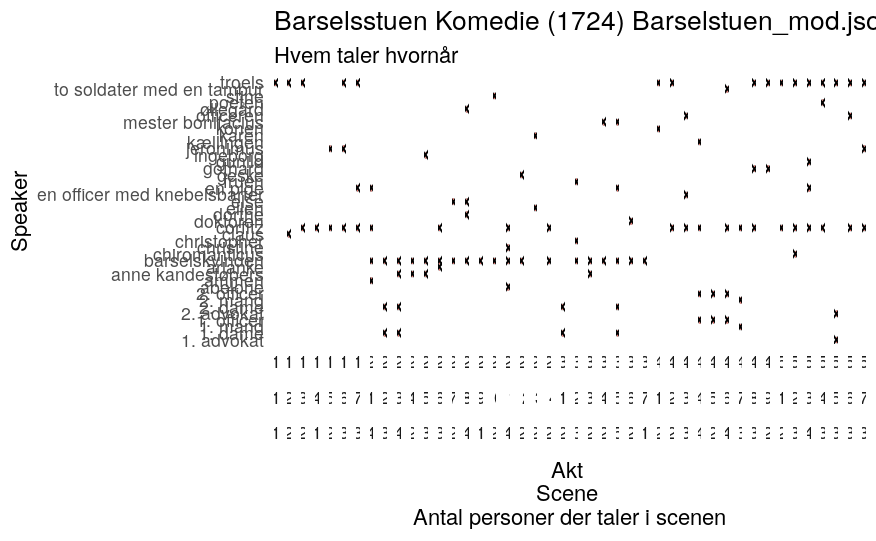

```r
#Plot
my_summary %>%
  ggplot(aes(y = speaker, x = scene_index, width = 100)) +
    geom_tile(aes(fill = boolean_spoke, colour = speaker), colour = "grey", show.legend = FALSE) +
    geom_text(aes(label = "X")) +
    labs(
      title = paste(my_title, my_year, my_file),
      subtitle = "Hvem taler hvornår"
    ) +
  xlab("Akt \nScene \nAntal personer der taler i scenen") +
  ylab("Speaker") +
  theme(axis.text.x=element_blank(), line = element_blank(), rect = element_blank()) +
  facet_grid(cols = vars("act_number" = act_number, "scene_number" = scene_number, "total" = total), switch="x")

  ggsave(here("graphs/plots", paste(my_file, ".hvem_taler_hvornaar.pdf")), width=16, height=9)
```

```r
NA
NA
```

#Graf over hvem der er til stede Vi tilføjer til grafen ovenfor?!

```r
# Vi genindlæser lige stykket!
my_play <- read_play_jsonl(here("test-data", my_file))
# Til stede, men taler ikke
present_without_speech_numbers(my_play) %>%
  # add a scene index for the x-axis
  rowwise() %>%
  mutate(scene_index = calc_scene_index(act_number, scene_number, act_length)) %>%
  # add a boolean for "til stede"
    mutate(boolean_spoke = "S") %>%
  select(-index) -> present_silent
# Sæt "taler" og "til stede" sammen
my_summary %>%
    select(-total) %>%
  full_join(present_silent,
            by = c("speaker"="word", "act_number", "scene_number", "scene_index", "boolean_spoke")) -> new_summary

#Husk at tælle hvor mange der NU er på scenen
(new_summary %>%
  group_by(act_number, scene_number) %>%
  mutate(total = sum(n_distinct(speaker))) -> new_summary)
```

| act_number | scene_number | scene_index | speaker | boolean_spoke | total |
| --- | --- | --- | --- | --- | --- |
| 1 | 1 | 1 | troels | X | 1 |
| 1 | 2 | 2 | claus | X | 2 |
| 1 | 2 | 2 | troels | X | 2 |
| 1 | 3 | 3 | corfitz | X | 2 |
| 1 | 3 | 3 | troels | X | 2 |
| 1 | 4 | 4 | corfitz | X | 1 |
| 1 | 5 | 5 | jeronimus | X | 2 |
| 1 | 5 | 5 | corfitz | X | 2 |
| 1 | 6 | 6 | troels | X | 3 |
| 1 | 6 | 6 | corfitz | X | 3 |

[output cut: 120 more lines]

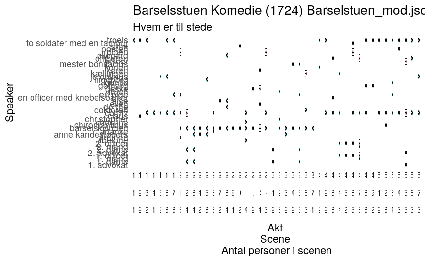

```r
new_summary %>%
  ggplot(aes(y = speaker, x = scene_index, width = 100)) +
    geom_tile(aes(fill = boolean_spoke, colour = speaker), colour = "grey", show.legend = FALSE) +
    geom_text(aes(label = boolean_spoke)) +
    labs(
      title = paste(my_title, my_year, my_file),
      subtitle = "Hvem er til stede"
    ) +
  xlab("Akt \nScene \nAntal personer i scenen") +
  ylab("Speaker") +
  theme(axis.text.x=element_blank(), line = element_blank(), rect = element_blank()) +
  facet_grid(cols = vars("act_number" = act_number, "scene_number" = scene_number, "total" = total), switch = "x")
```

```r
  #ggsave(here("graphs/plots", paste(my_file, ".hvem_til_stede.pdf")), width=16, height=9)
```

#Graf over omtale

Først skal vi definere omtale. Jeg tænker at vi gør det ligesom med ‘ikke til stede’. Altså hvis en karakter optræder i en replik i en scene, hvor den karakter ikke selv er til stede, bliver den karakter omtalt.

Vi tilføjer til grafen ovenfor?!

```r
source(here("src", "omtale.R"))
(spoken_about(my_play) %>%
  # add a scene index for the x-axis
  rowwise() %>%
  mutate(scene_index = calc_scene_index(act_number, scene_number, act_length)) %>%
  # add a boolean for "omtalt"
    mutate(boolean_spoke = "O") %>%
  select(-index)
  -> spoken_about_summary)
```

| act_number | scene_number | word | scene_index | boolean_spoke |
| --- | --- | --- | --- | --- |
| 1 | 1 | abelone | 1 | O |
| 1 | 1 | christine | 1 | O |
| 1 | 1 | christopher | 1 | O |
| 1 | 1 | ellen | 1 | O |
| 1 | 1 | geske | 1 | O |
| 1 | 1 | anne | 1 | O |
| 1 | 1 | ingeborg | 1 | O |
| 1 | 1 | dorthe | 1 | O |
| 1 | 1 | øllegård | 1 | O |
| 1 | 1 | karen | 1 | O |

[output cut: 44 more lines]

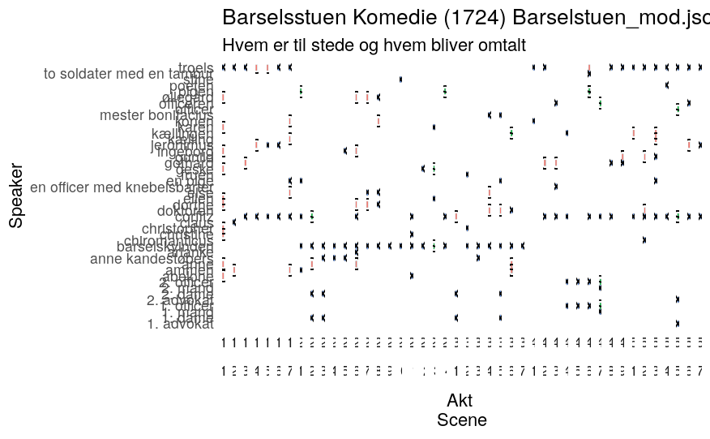

```r
new_summary %>%
    select(-total) %>%
  full_join(spoken_about_summary, by = c("speaker"="word", "act_number", "scene_number", "scene_index", "boolean_spoke")) %>%
  ggplot(aes(y = speaker, x = scene_index, width = 100)) +
    geom_tile(aes(fill = boolean_spoke, colour = speaker), colour = "grey", show.legend = FALSE) +
    geom_text(aes(label = boolean_spoke)) +
    labs(
      title = paste(my_title, my_year, my_file),
      subtitle = "Hvem er til stede og hvem bliver omtalt"
    ) +
  xlab("Akt \nScene") +
  ylab("Speaker") +
  theme(axis.text.x=element_blank(), line = element_blank(), rect = element_blank()) +
  facet_grid(cols = vars("act_number" = act_number, "scene_number" = scene_number), switch = "x")
```

```r
  #ggsave(here("graphs/plots", paste(my_file, ".hvem_til_stede_hvem_omtalt.pdf")), width=16, height=9)
```

# Kør funktionerne på alle stykker

Vi tester lige med et enkelt først

```r
plot_all(my_file)
```

Nu på alle stykker

```r
source(here("src", "plot_func.R"))
# Alle stykker som json filer
json_file_list <- list.files(here("test-data"), pattern = "*.jsonl")
# Alle stykker som plots
for(i in 2:length(json_file_list)) {
  plot_all(json_file_list[i])
  print(paste("plotting play nr.",i,"of",length(json_file_list)))
}
```

```
[1] "plotting play nr. 2 of 37"
[1] "plotting play nr. 3 of 37"
[1] "plotting play nr. 4 of 37"
[1] "plotting play nr. 5 of 37"
[1] "plotting play nr. 6 of 37"
[1] "plotting play nr. 7 of 37"
[1] "plotting play nr. 8 of 37"
[1] "plotting play nr. 9 of 37"
[1] "plotting play nr. 10 of 37"
[1] "plotting play nr. 11 of 37"
[1] "plotting play nr. 12 of 37"
[1] "plotting play nr. 13 of 37"
[1] "plotting play nr. 14 of 37"
[1] "plotting play nr. 15 of 37"
[1] "plotting play nr. 16 of 37"
```

[output cut: 21 more lines]